# Estimating a Poincaré Section of the Lorenz Attractor (Assignment Sheet 10)

Introduction To Chaos Applied To Systems, Processes And Products (ETSIDI, UPM)

Alfonso Allen-Perkins, Juan Carlos Bueno, and Eduardo Faleiro

2025-05-05

# Introduction

A **Poincaré section** is a fundamental tool in the study of dynamical systems. It provides a lower-dimensional snapshot of a system’s trajectory, helping us understand the structure of chaotic attractors. In this assignment, we estimate a Poincaré section of the **Lorenz attractor**, a classical example of deterministic chaos.

1. Load Required Packages

```r
library(deSolve)
library(ggplot2)
library(dplyr)
```

2. Define the Lorenz System

```r
lorenz <- function(t, state, parameters) {
  with(as.list(c(state, parameters)), {
    dx <- sigma * (y - x)
    dy <- x * (rho - z) - y
    dz <- x * y - beta * z
    list(c(dx, dy, dz))
  })
}

parameters <- c(sigma = 10, rho = 28, beta = 8/3)
state <- c(x = 1, y = 1, z = 1)
times <- seq(0, 100, by = 0.01)

out <- as.data.frame(ode(y = state, times = times, func = lorenz, parms = parameters))
```

3. Estimate the Poincaré Section

We’ll compute the Poincaré section by detecting trajectory crossings through the plane $z = 25$, keeping only the points where the trajectory crosses **from below** (i.e., positive slope in $z$).

```r
# Approximate Poincare section at z = 25
z_target <- 25
crossings <- which(diff(out$z > z_target) == 1)  # upward crossings

# Linear interpolation to get better crossing point estimates
poincare_points <- data.frame()
for (i in crossings) {
  x0 <- out[i, ]
  x1 <- out[i + 1, ]
  alpha <- (z_target - x0$z) / (x1$z - x0$z)
  x_cross <- x0$x + alpha * (x1$x - x0$x)
  y_cross <- x0$y + alpha * (x1$y - x0$y)
  poincare_points <- rbind(poincare_points, data.frame(x = x_cross, y = y_cross))
}
```

4. Visualize the Poincaré Section

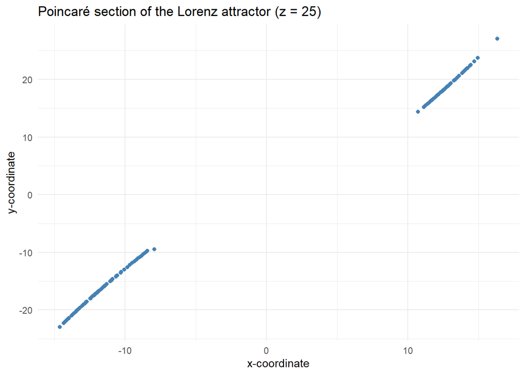

```r
ggplot(poincare_points, aes(x = x, y = y)) +
  geom_point(color = "steelblue") +
  theme_minimal() +
  labs(title = "Poincaré section of the Lorenz attractor (z = 25)",
       x = "x-coordinate", y = "y-coordinate")
```

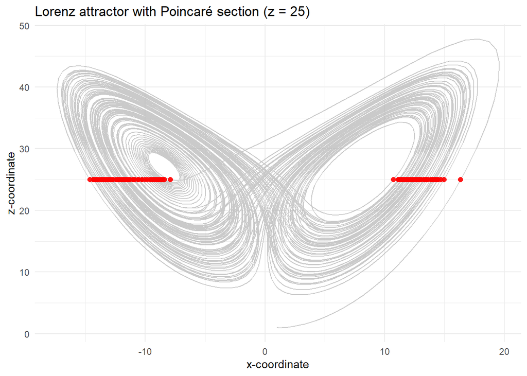

```r
# Full trajectory in (x, z), with Poincaré section overlaid
ggplot() +
  geom_path(data = out,
            aes(x = x, y = z), color = "grey70", alpha = 0.7) +
  geom_point(data = poincare_points, aes(x = x, y = z_target),
             color = "red", size = 2, alpha = 0.9) +
  theme_minimal() +
  labs(title = "Lorenz attractor with Poincaré section (z = 25)",
       x = "x-coordinate", y = "z-coordinate")
```

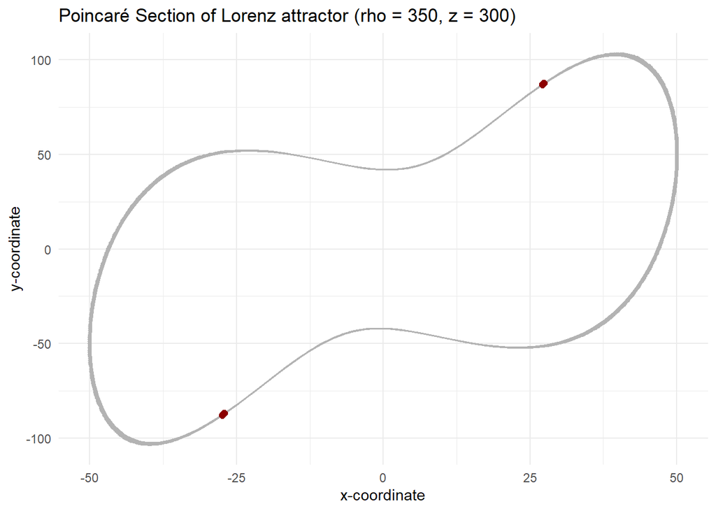

```r
# Change parameters to a periodic regime
parameters_periodic <- c(sigma = 10, rho = 350, beta = 8/3)
state <- c(x = 1, y = 1, z = 1)
times <- seq(0, 100, by = 0.01)

out_periodic <- as.data.frame(ode(y = state,
                                  times = times,
                                  func = lorenz,
                                  parms = parameters_periodic))  %>% filter(time > 90)

# Estimate Poincaré section as before
z_target <- 300
crossings_p <- which(diff(out_periodic$z > z_target) == 1)

poincare_periodic <- data.frame()
for (i in crossings_p) {
  p0 <- out_periodic[i, ]
  p1 <- out_periodic[i + 1, ]
  alpha <- (z_target - p0$z) / (p1$z - p0$z)
  x_cross <- p0$x + alpha * (p1$x - p0$x)
  y_cross <- p0$y + alpha * (p1$y - p0$y)
  poincare_periodic <- rbind(poincare_periodic, data.frame(x = x_cross,
                                                           y = y_cross,
                                                           z = z_target))
}

# Plot
ggplot() +
  geom_path(data = out_periodic,
            aes(x = x, y = y), color = "grey70") +
  geom_point(data = poincare_periodic, aes(x = x, y = y), color = "darkred", size = 2) +
  theme_minimal() +
  labs(title = "Poincaré Section of Lorenz attractor (rho = 350, z = 300)",
       x = "x-coordinate", y = "y-coordinate")
```

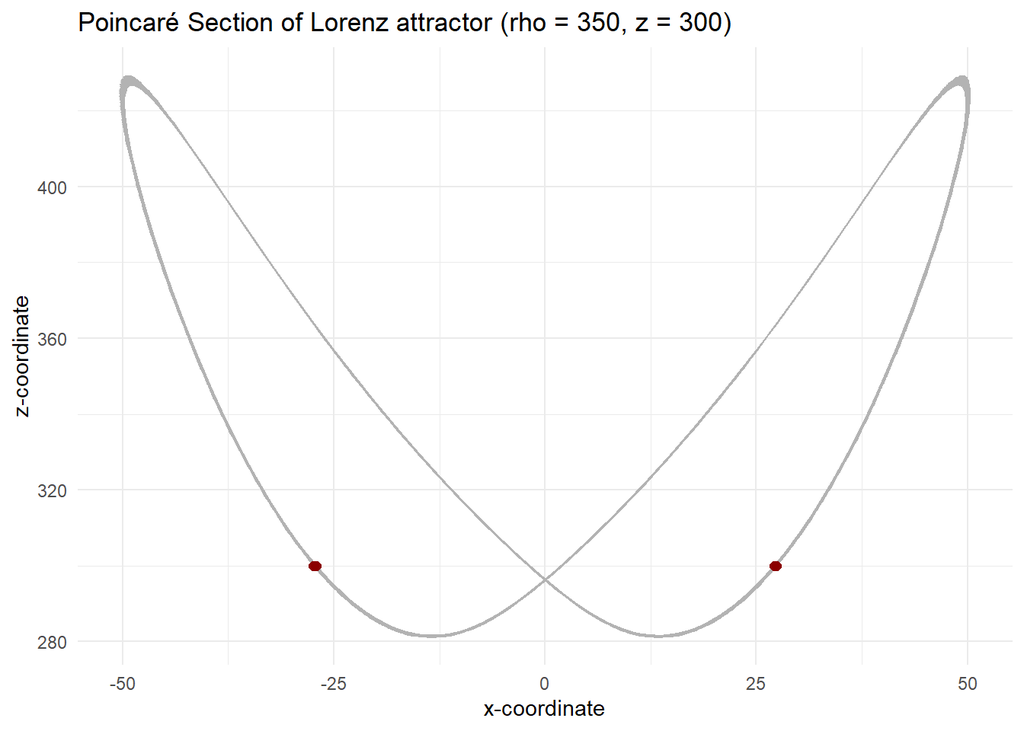

```r
# Plot
ggplot() +
  geom_path(data = out_periodic,
            aes(x = x, y = z), color = "grey70") +
  geom_point(data = poincare_periodic, aes(x = x, y = z), color = "darkred", size = 2) +
  theme_minimal() +
  labs(title = "Poincaré Section of Lorenz attractor (rho = 350, z = 300)",
       x = "x-coordinate", y = "z-coordinate")
```

# Suggestions for Exploration

- Try different values for the section plane (e.g., `z = 20`, `z = 30`).
- Use more precise numerical solvers or finer time steps to better capture crossings.
- Explore projections in other planes (e.g., `y = const`).